## Wright-Fisher model (of allelic frequency progression)

**Assumptions:**

- Random mating
- Constant number of non-overlapping individuals between generations
- No selective pressure

**Components** * 50/50 inheritance likelihood (Bernoulli) -> Binomial draw (p=AF=Allele Frequency) gives population count * For diploid model, an N population gives a 2N allele sample size

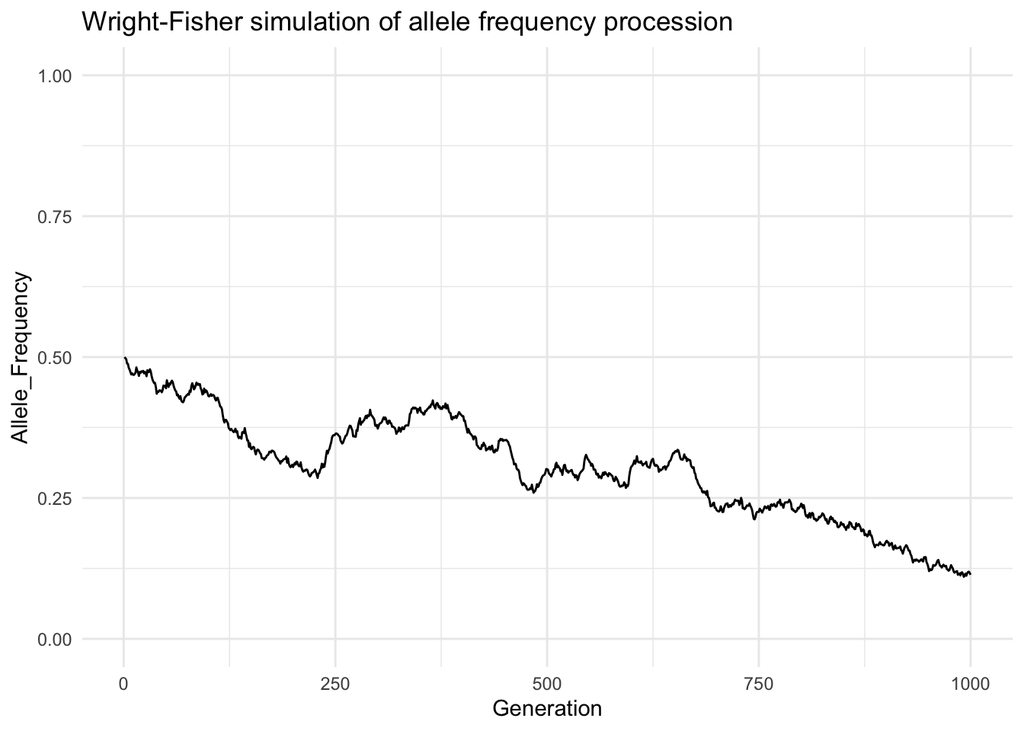

```r
binom_WF <- function(generations, pop_size, freq_init) {
  AFs = c(freq_init)
  for (i in 1:(generations-1)) {
    AFs <- c(AFs, rbinom(n = 1, size = pop_size, prob = AFs[length(AFs)]) / pop_size)
  }
  return(data.frame(`Allele_Frequency` = AFs, Generation = 1:(generations)))
}

results <- binom_WF(generations=1000, pop_size=10000, freq_init=0.5)

ggplot(data = results, aes(x = Generation, y = `Allele_Frequency`)) +
  geom_line() +
  theme_minimal() +
  ylim(0, 1) +
  ggtitle("Wright-Fisher simulation of allele frequency procession")
```

## Assignment

One way to extend our simple Wright-Fisher model is to add in selection as a parameter. Selection affects our model by altering the probability of sampling our allele of interest each generation (e.g., positive selection increases the probability, and negative selection decreases it).

Previously, we assumed that this probability was equivalent to the allele’s frequency, or $p = \frac{i}{N_e}$, where $N_e$ is the population size and $i$ is the number of individuals who carry the allele.

For the purposes of this homework, we assume that in a model with selection, this probability is instead:

$$p = \frac{i(1 + s)}{N_e - i + i(1+s)}$$

where $s$ is the **selection coefficient**, and ranges from `-1` to `1`.

### TASK: sweep |s|<0.05

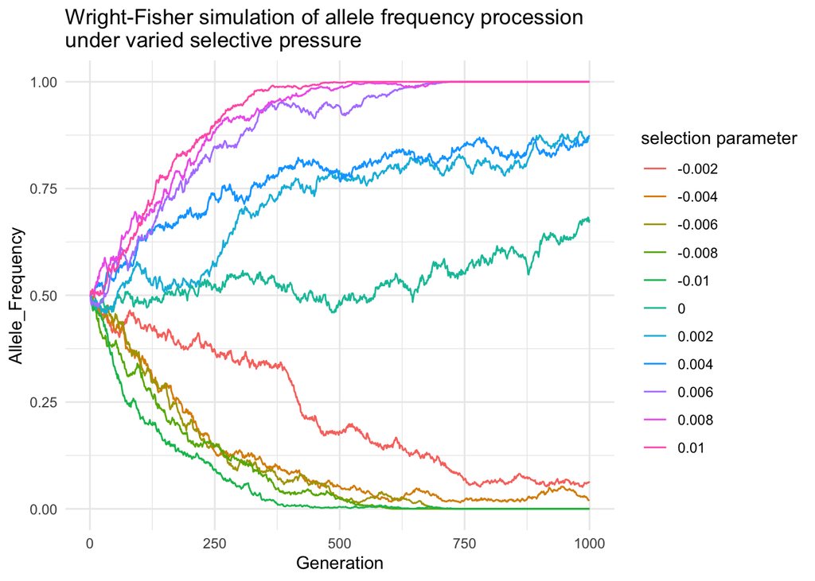

```r
selective_WF <- function(s, generations, pop_size, freq_init) {
  AFs = c(freq_init)

  for (i in 1:(generations-1)) {

    i = pop_size*AFs[length(AFs)]
    p = i*(1+s) / (pop_size - i + i*(1+s))

    AFs = c(AFs, rbinom(n = 1, size = pop_size, prob = p) / pop_size)
  }
  return(data.frame(`Allele_Frequency` = AFs, Generation = 1:(generations)))
}

results <- lapply(seq(-1e-2, 1e-2, 2e-3), selective_WF, generations=1000, pop_size=10000, freq_init=0.5) %>%
  `names<-`(seq(-1e-2, 1e-2, 2e-3)) %>%
  bind_rows(.id = "selection parameter")

ggplot(data = results, aes(x = Generation, y = `Allele_Frequency`, color=`selection parameter`)) +
  geom_line() +
  theme_minimal() +
  ylim(0, 1) +
  ggtitle("Wright-Fisher simulation of allele frequency procession\nunder varied selective pressure")
```

Note that most selection coefficients are thought to be [extremely small](https://journals.plos.org/plosgenetics/article/figure?id=10.1371/journal.pgen.1004697.g002) – the largest known selection coefficients in humans are around [0.05](https://elifesciences.org/articles/63177).

## Further notes:

### Adaptations:

- To model inbreeding, a population size of equivalent produced variance is used (inbreeding effective population numbers)
- Separate sexes (see textbook)
- Monogamy (see textbook)
- Varying population size (see textbook)

### Predictions:

While beyond this project’s scope, the WF model predicts (for the diploid case):

(Below citing Crow, J. F. & Kimura, M. (1970). An Introduction to Population Genetics Theory)

## 1) Decay of heterozygosity

**Setup.** For a diploid Wright–Fisher population of size $N$ let $p_t$ be the frequency of allele $A$ in generation $t$. Define heterozygosity

$$H_t \;=\; \Pr(\text{two randomly drawn alleles (with replacement) are
different}) \;=\; 2\,\mathbb{E}[p_t(1-p_t)].$$

(Equivalently $H_t=1-\sum_i p_{i,t}^2$ for more alleles; for two alleles $H_t=2p_t(1-p_t)$.)

**One-step conditional moments (binomial sampling).** Given $p_t$,

$$\mathbb{E}[p_{t+1}\mid p_t]=p_t,\qquad
\operatorname{Var}(p_{t+1}\mid p_t)=\frac{p_t(1-p_t)}{2N}$$

(for diploids — if you model gametes sampling $2N$ draws, the variance is $p_t(1-p_t)/(2N)$).

Compute the conditional expectation of $p_{t+1}(1-p_{t+1})$:

$$\begin{aligned}
\mathbb{E}[p_{t+1}(1-p_{t+1})\mid p_t]
&= \mathbb{E}[p_{t+1}\mid p_t] - \mathbb{E}[p_{t+1}^2\mid p_t] \\
&= p_t - \big(\operatorname{Var}(p_{t+1}\mid p_t) +
(\mathbb{E}[p_{t+1}\mid p_t])^2\big)\\
&= p_t - \Big(\frac{p_t(1-p_t)}{2N} + p_t^2\Big)\\
&= p_t(1-p_t)\Big(1 - \frac{1}{2N}\Big).
\end{aligned}$$

Take expectations over $p_t$ to get the unconditional recursion

$$\mathbb{E}[p_{t+1}(1-p_{t+1})] \;=\; \Big(1 -
\frac{1}{2N}\Big)\mathbb{E}[p_t(1-p_t)].$$

Multiply by 2 to get heterozygosity:

$$H_{t+1} \;=\; \Big(1 - \frac{1}{2N}\Big) H_t .$$

Iterating,

$$\boxed{\,H_t \;=\; H_0 \Big(1 - \frac{1}{2N}\Big)^t \, }$$

which for large $N$ and moderate $t$ is well approximated by the exponential

$$H_t \approx H_0 \exp\!\Big(-\frac{t}{2N}\Big).$$

## 2) Time to fixation / absorption

We consider the time until absorption (either allele fixed or lost). Let $T$ be the time to absorption (first time $p_t\in\{0,1\}$). We derive the expected time to absorption starting from frequency $p$ using the diffusion approximation (valid for large $N$).

**Backward equation (diffusion approximation).** Under the neutral diffusion approximation the generator for the allele-frequency process yields the following ordinary differential equation for the expected time to absorption $u(p)=\mathbb{E}_p[T]$:

$$\frac{1}{2}\,\sigma^2(p)\,u''(p) \;=\; -1,$$

with $\sigma^2(p)=\dfrac{p(1-p)}{2N}$ (the diffusion variance). Substituting,

$$\frac{1}{2}\cdot\frac{p(1-p)}{2N}\,u''(p) = -1
\quad\Longrightarrow\quad
u''(p) = -\frac{4N}{p(1-p)}.$$

Integrate twice. First integral:

$$u'(p) = -4N \int \frac{dp}{p(1-p)} + C_1
= -4N \ln\!\frac{p}{1-p} + C_1.$$

Second integral:

$$u(p) = -4N\big( p\ln p + (1-p)\ln(1-p)\big) + C_1 p + C_2.$$

Boundary conditions for absorption time: $u(0)=u(1)=0$. Using these conditions (and limits $p\ln p\to0$ as $p\to0$), one finds $C_1=C_2=0$. Thus

$$\boxed{\,u(p) \;=\; -4N\big[ p\ln p + (1-p)\ln(1-p) \big] \,}$$

is the **expected time to absorption (either fixation or loss)** starting from frequency $p$.

**Special cases / approximations.**

- If the allele is initially at frequency $p=\tfrac{1}{2}$: